# Lab 5

Evie Vermeer

10/25/2021

```r
knitr::opts_chunk$set(echo = TRUE, message = FALSE, warning = FALSE)

library(tidyverse)
library(effsize)
```

## Part 1: Confidence Intervals

In this section, we’ll use the t.test() function to calculate confidence intervals

### Example 1

Create a single mock sample containing a number of values, then learn to use t.test() to return confidence intervals, and learn about in-line code referencing so our tesxt becomes more reproducible, too.

```r
# Create a mock sample - using c() to create a vector

otter_lengths <- c(30,28,22,25,32,26,54,45,42)

# Find the confidence interval from our sample:

otter_ci <- t.test(otter_lengths)

# Find the standard deviation

otter_sd <- sd(otter_lengths)

n_otter <- length(otter_lengths)
```

95% confidence interval means that if you took multiple samples from this population, you’d expect 95% of those sample confidence intervals to contain the true population mean.

Mean otter length is 33.8 ($\pm$ 10.8, n=9) inches with a 95% confidence interval of [25.5,42.1] inches.

#### Now, using in-line referencing

Mean otter length is 33.8 inches, with a 95% confidence interval of [25.5,42.1] inches.

## Part 2: Two-sample t-tests

### Example 1

Make two mock samples, ask the question: do we have sufficient evidence to make us reject the null hypothesis that these samples were drawn from populations with the same mean.

```r
# Make my mock samples

oak_trees <- c(45,39,44,60,43)

pine_trees <- c(85,72,76,77,105,69)

# Two-sample t-test
tree_t <- t.test(oak_trees,pine_trees)

# Null hypothesis means heights are the same
#i.e. : Trees are drawn from populations with the same mean height
```

“t(df) = t-statistic, p = p-value”

*AVOID* p=0 When things get really small, use P < 0.001

## Part 3: Another t-test with car data

### Take a look at the data

```r
compact_suv <- mpg %>%
  filter(class %in% c("compact","suv"))
# Check for remaining levels

unique(compact_suv$class)
```

```
## [1] "compact" "suv"
```

Create a histogram of city (cty) gas mileage, faceted by class, starting from compact_suv

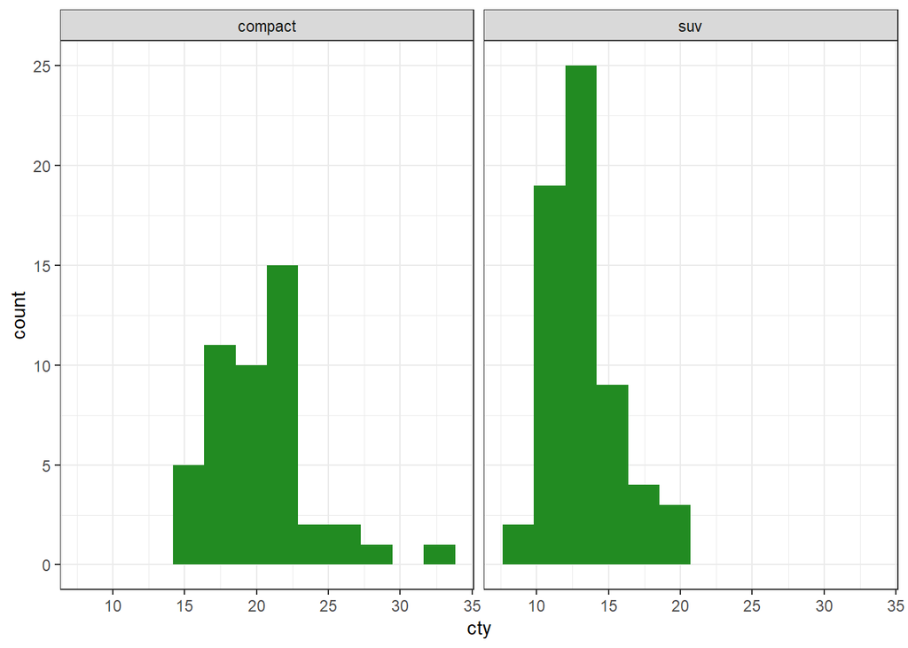

```r
ggplot(compact_suv,aes(x=cty))+
geom_histogram(bins = 12, fill="forestgreen") +
  theme_bw()+
  facet_wrap(~class)
```

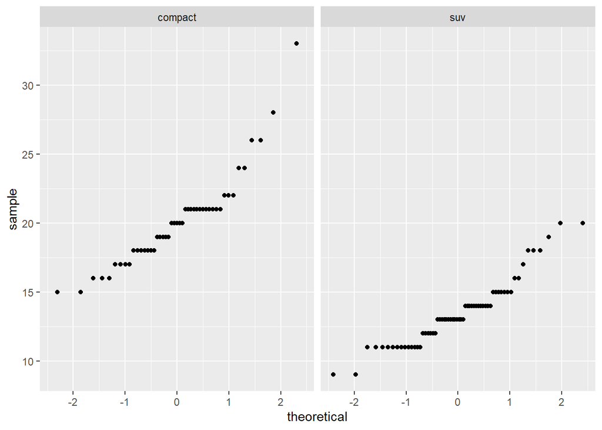

```r
ggplot(data = compact_suv, aes(sample = cty))+
  geom_qq()+
  facet_wrap(~class)
```

Find some summary statistics for each group

```r
car_stats <- compact_suv %>%
  group_by(class) %>%
  summarize(
    mean_city = round(mean(cty),2),
    sd_city = round(sd(cty),2),
    sample_size = n()         )
```

The t.test function REALLY wants vectors of things.

```r
compact_sample <- compact_suv %>%
  filter(class == "compact") %>%
  pull(cty)

# Your turn, do the same thing to get a vector of city gas mileages for SUVS

suv_sample <- compact_suv %>%
  filter(class == "suv") %>%
  pull(cty)
```

H0: Mean city gas mileages for SUVS and compact cars are the same

```r
t.test(compact_sample,suv_sample)
```

```
##
##  Welch Two Sample t-test
##
## data:  compact_sample and suv_sample
## t = 11.393, df = 79.558, p-value < 2.2e-16
## alternative hypothesis: true difference in means is not equal to 0
## 95 percent confidence interval:
##  5.469914 7.785405
## sample estimates:
## mean of x mean of y
##  20.12766  13.50000
```